# When It Comes to Crime by Neighborhood, Do Socioeconomic Factors Tell the Whole Story?

Michael Morello

2025-04-03

# Introduction

Gun violence in New York City has steadily declined in recent years, but disparities remain—both in the lived experience of crime and in the public’s perception of safety. While many studies have explored the social determinants of violence, this research takes a broader approach by examining how social and environmental factors interact to shape neighborhood outcomes. A central focus of this analysis is New York State’s “Disadvantage Score,” a composite measure designed to capture the cumulative environmental, health, and socioeconomic burdens experienced by communities.

This score—ranging from 0 to 1, with higher values indicating greater structural disadvantage—offers a unique lens for understanding the systemic conditions that may underlie violence, poverty, and inequity. The data used in this study comes from the 2023 NYC Disadvantaged Neighborhoods Dataset, developed by the New York State Department of Environmental Conservation (NYSDEC) in partnership with the New York State Climate Justice Working Group. This dataset integrates 45 indicators spanning pollution exposure, housing quality, healthcare access, poverty rates, and historical disinvestment.

The aim of this analysis is to identify and evaluate the key predictors that most strongly influence the Disadvantage Score across NYC neighborhoods. By doing so, I hope to uncover patterns of structural inequality and contribute to a larger project examining the relationship between disadvantage and gun violence. The ultimate goal is to inform more equitable policy interventions—ones that not only address crime, but also the underlying conditions that allow it to persist.

## Research Objectives

The primary objective of this analysis is to evaluate which environmental, population, and health-related factors have the greatest impact on New York City’s Disadvantage Score—a composite metric designed to capture cumulative structural burdens in each neighborhood. Using beta regression modeling and simulation, I aim to assess not only the statistical significance but also the real-world magnitude of each variable’s effect. This work also seeks to explore the usefulness of the Disadvantage Score as a tool for analyzing broader social issues, including patterns of gun violence. By identifying the strongest predictors of disadvantage and understanding their connection to crime and community vulnerability, this research provides a data-driven foundation for equity-focused policy, targeted interventions, and a deeper understanding of how environmental and social factors intersect to shape neighborhood outcomes.

## Hypothesis

This analysis is grounded in the hypothesis that gun violence is more likely to be concentrated in neighborhoods facing a combination of environmental burdens and social inequities. These intersecting stressors—such as pollution exposure, limited green space, poor health outcomes, and socioeconomic hardship—create conditions that may heighten vulnerability to violence. As such, these areas should be seen as priority zones for targeted intervention and resource investment. A second, related hypothesis is that the Disadvantage Score itself serves as a strong and reliable indicator for identifying communities at heightened risk. If neighborhoods with higher Disadvantage Scores consistently correlate with increased rates of gun violence, it would support the utility of this metric as a meaningful tool for understanding structural conditions that contribute to crime. Together, these hypotheses frame the analysis around understanding not only which factors matter most, but how they may collectively inform more equitable and strategic approaches to violence prevention.

# Cleaning NYC Disadvantaged Neighborhood Data For Beta Regression Analysis

Before running the beta regression, I examined the Percentile_Rank_Combined_NYC variable to ensure it met the assumptions of the model. Beta regression requires the dependent variable to lie strictly between 0 and 1. To check for violations of this assumption, I used a logical test to count how many neighborhoods had scores that were exactly 0 or 1.

```
##
## FALSE  TRUE
##  2093  2825
```

The result showed that 2,825 observations had values at the boundaries, while only 2,093 fell strictly within the valid range. Since a substantial portion of the data did not meet the model’s requirements, this highlighted the need to transform the variable to ensure all values fall within the open interval (0, 1) prior to model fitting.

After identifying that over half of the Percentile_Rank_Combined_NYC values were exactly 0 or 1—violating the assumptions of beta regression, I proceeded to transform the variable to make it suitable for modeling. Beta regression requires the dependent variable to fall strictly within the open interval (0, 1), so a common transformation was applied to shift all values slightly inward while preserving their rank order. This transformation is especially important when dealing with proportion or percentile data that include boundary values.

This formula adjusts the original values so that any 0s or 1s are slightly shifted inward, ensuring all transformed values fall strictly within the range (0, 1). Specifically, a value of 0 becomes 0.5 / n and a value of 1 becomes (n - 0.5) / n. In this data set, where n = 4918, a value of 0 is transformed to approximately 0.0001, and a value of 1 is transformed to approximately 0.9999. These adjustments are minimal but crucial. They allow the data to satisfy the assumptions of the beta distribution without altering the overall structure or relative rankings of the scores. The resulting score_transformed variable is now compatible with beta regression and still accurately reflects the original disadvantage levels across neighborhoods.

# Beta Regression Models

With the score_transformed variable properly adjusted to fall within the (0, 1) interval, the data set was now ready for regression modeling. Given the bounded and continuous nature of the outcome variable, beta regression was selected as the appropriate analytical approach. This method is particularly well-suited for modeling proportion-based outcomes and allows for interpreting how various predictor variables influence neighborhood-level disadvantage. To explore different dimensions of structural inequity, I developed two separate models: the first (m2) focused on environmental burdens and climate change-related risk factors, while the second (m3) examined population characteristics, socioeconomic indicators, and health-related vulnerabilities. Together, these models provide a multifaceted understanding of the forces shaping disadvantage across NYC neighborhoods.

# Environmental Burdens and Climate Change Risk Factors Regression Analysis

To examine the relationship between environmental burdens, climate change risk factors, and neighborhood disadvantage, I fit a beta regression model using the betareg() function in R. The outcome variable, score_transformed, is a normalized version of the overall disadvantage score, adjusted to meet the requirements of beta regression. The model (m2) includes predictor variables that reflect exposure to environmental hazards and climate-related stressors. These include air pollution (Particulate_Matter_25), traffic density, proximity to industrial and hazardous land uses (e.g., Landfills, Oil_Storage, Municipal_Waste_Combustors), and long-term land use impacts (e.g., Agricultural_Land_Use, Industrial_Land_Use). Climate change-related risk is captured through indicators like Days_Above_90_Degrees_2050 and Low_Vegetative_Cover, while Drive_Time_Healthcare accounts for access to healthcare in vulnerable communities. This model allows us to assess how these environmental and climate-related stressors contribute to patterns of disadvantage across NYC neighborhoods. The indicators along with their definitions can be seen in the table below.

## Environmental Burdens and Climate Change Risk Variables Data Dictionary

Data Dictionary for Environmental Burden and Climate Risk Variables (Model m2)

| Variable | Definition |
| --- | --- |
| Particulate_Matter_25 | Percentile ranking of the average annual concentration of PM2.5 (particulate matter ≤ 2.5 microns) per cubic meter. |
| Traffic_Truck_Highways | Percentile ranking of average daily truck traffic on highways (Classes 4–13 vehicles). |
| Traffic_Number_Vehicles | Percentile ranking of average daily vehicle traffic on major roads within 500 meters of census block centroids, weighted by population. |
| Wastewater_Discharge | Percentile ranking of toxicity-weighted concentrations in stream segments near the tract, indicating potential water pollution. |
| Industrial_Land_Use | Percentile ranking of census tract land area zoned for industrial, mining, or manufacturing use. |
| Landfills | Percentile ranking of land area within 500 meters of an active landfill. |
| Oil_Storage | Percentile ranking of land area within 500 meters of major oil storage facilities. |
| Municipal_Waste_Combustors | Percentile ranking of land area within 500 meters of a municipal waste combustor. |
| Power_Generation_Facilities | Percentile ranking of land area within 1 mile of fossil-fuel-burning power plants or peaker units. |
| RMP_Sites | Percentile ranking of proximity to chemical accident risk sites (Regulated Management Plan sites), weighted by distance and population. |
| Remediation_Sites | Percentile ranking of the number of state/federal environmental remediation sites (e.g., Superfund, Brownfield). |
| Scrap_Metal_Processing | Percentile ranking of the number of scrap metal and vehicle dismantling facilities. |
| Agricultural_Land_Use | Percentile ranking of land area used for crops or pasture. |
| Days_Above_90_Degrees_2050 | Projected percentile ranking of the average annual number of days above 90°F in the year 2050. |
| Low_Vegetative_Cover | Percentile ranking of the census tract land area classified as developed or barren (low vegetation). |
| Drive_Time_Healthcare | Percentile ranking of average drive time from the tract center to the three nearest healthcare facilities. |

## Beta Regression Model of Enviromental Burdens and Climate Change Risk Factors

The below section of the code fits a beta regression model to examine how various environmental burdens and climate-related factors contribute to neighborhood disadvantage in New York City. The betareg() function is used because the dependent variable, score_transformed, is a continuous proportion bounded between 0 and 1—a requirement of beta regression. The model (m2) includes 16 independent variables representing air pollution, traffic exposure, industrial land use, environmental hazards, climate vulnerability, and healthcare access.

Key variables include particulate matter (PM2.5), truck traffic, proximity to industrial sites, projected extreme heat, vegetative cover, and drive time to healthcare facilities. These predictors are drawn from the neighborhoods data set and modeled against the transformed disadvantage score.

The final line, summary(m2), displays detailed model output including coefficient estimates, standard errors, z-values, and significance levels for each predictor. This output provides insight into the strength and direction of the relationship between each environmental factor and the predicted disadvantage score.

```
##
## Call:
## betareg(formula = score_transformed ~ Particulate_Matter_25 + Traffic_Truck_Highways +
##     Traffic_Number_Vehicles + Wastewater_Discharge + Industrial_Land_Use +
##     Landfills + Oil_Storage + Municipal_Waste_Combustors + Power_Generation_Facilities +
##     RMP_Sites + Remediation_Sites + Scrap_Metal_Processing + Agricultural_Land_Use +
##     Days_Above_90_Degrees_2050 + Low_Vegetative_Cover + Drive_Time_Healthcare,
##     data = neighborhoods)
##
## Quantile residuals:
##     Min      1Q  Median      3Q     Max
## -3.3397 -0.6490 -0.1935  0.3369  3.8470
##
## Coefficients (mean model with logit link):
##                               Estimate Std. Error z value Pr(>|z|)
## (Intercept)                 -4.6920941  0.1096509 -42.791  < 2e-16 ***
## Particulate_Matter_25        1.4614179  0.0970630  15.056  < 2e-16 ***
## Traffic_Truck_Highways       0.5253232  0.0821892   6.392 1.64e-10 ***
## Traffic_Number_Vehicles     -0.1896538  0.1080662  -1.755   0.0793 .
## Wastewater_Discharge        -0.2426377  0.0565219  -4.293 1.76e-05 ***
## Industrial_Land_Use          0.0728741  0.0573163   1.271   0.2036
## Landfills                   -0.2771025  0.2282063  -1.214   0.2246
## Oil_Storage                 -0.1529130  0.1265882  -1.208   0.2271
## Municipal_Waste_Combustors  -0.5420505  0.3666539  -1.478   0.1393
## Power_Generation_Facilities  0.2994751  0.0990510   3.023   0.0025 **
## RMP_Sites                    0.0007567  0.0006812   1.111   0.2667
## Remediation_Sites           -0.2629478  0.0561514  -4.683 2.83e-06 ***
## Scrap_Metal_Processing       0.1884084  0.0782322   2.408   0.0160 *
## Agricultural_Land_Use        1.1163217  0.0876453  12.737  < 2e-16 ***
## Days_Above_90_Degrees_2050   0.8657231  0.0665122  13.016  < 2e-16 ***
## Low_Vegetative_Cover         2.8012651  0.1137205  24.633  < 2e-16 ***
## Drive_Time_Healthcare        0.0410721  0.0898107   0.457   0.6474
##
## Phi coefficients (precision model with identity link):
##       Estimate Std. Error z value Pr(>|z|)
## (phi)  1.68927    0.03702   45.63   <2e-16 ***
## ---
## Signif. codes:  0 '***' 0.001 '**' 0.01 '*' 0.05 '.' 0.1 ' ' 1
##
## Type of estimator: ML (maximum likelihood)
## Log-likelihood: 1.592e+04 on 18 Df
## Pseudo R-squared: 0.7364
## Number of iterations: 80 (BFGS) + 3 (Fisher scoring)
```

[output not shown]

Beta Regression Results for Environmental and Climate Predictors (Model m2)

| component | Predictor | Estimate | Standard Error | Z Value | P Value |
| --- | --- | --- | --- | --- | --- |
| mean | (Intercept) | -4.6921 | 0.1097 | -42.7912 | 0.0000 |
| mean | Particulate_Matter_25 | 1.4614 | 0.0971 | 15.0564 | 0.0000 |
| mean | Traffic_Truck_Highways | 0.5253 | 0.0822 | 6.3916 | 0.0000 |
| mean | Traffic_Number_Vehicles | -0.1897 | 0.1081 | -1.7550 | 0.0793 |
| mean | Wastewater_Discharge | -0.2426 | 0.0565 | -4.2928 | 0.0000 |
| mean | Industrial_Land_Use | 0.0729 | 0.0573 | 1.2714 | 0.2036 |
| mean | Landfills | -0.2771 | 0.2282 | -1.2143 | 0.2246 |
| mean | Oil_Storage | -0.1529 | 0.1266 | -1.2080 | 0.2271 |
| mean | Municipal_Waste_Combustors | -0.5421 | 0.3667 | -1.4784 | 0.1393 |
| mean | Power_Generation_Facilities | 0.2995 | 0.0991 | 3.0234 | 0.0025 |
| mean | RMP_Sites | 0.0008 | 0.0007 | 1.1108 | 0.2667 |
| mean | Remediation_Sites | -0.2629 | 0.0562 | -4.6828 | 0.0000 |
| mean | Scrap_Metal_Processing | 0.1884 | 0.0782 | 2.4083 | 0.0160 |
| mean | Agricultural_Land_Use | 1.1163 | 0.0876 | 12.7368 | 0.0000 |
| mean | Days_Above_90_Degrees_2050 | 0.8657 | 0.0665 | 13.0160 | 0.0000 |
| mean | Low_Vegetative_Cover | 2.8013 | 0.1137 | 24.6329 | 0.0000 |
| mean | Drive_Time_Healthcare | 0.0411 | 0.0898 | 0.4573 | 0.6474 |
| precision | (phi) | 1.6893 | 0.0370 | 45.6301 | 0.0000 |

## Visualization of Model-Based Predictions at Minimum and Maximum Values for Enviromental Burdens and Climate Change Risk Factors

This section of the code is designed to visualize the effect of each predictor variable in the m2 model on the predicted disadvantage score, specifically by comparing predictions at the minimum and maximum values of each variable. After fitting the beta regression model (m2), the vars vector is created to list all 16 predictors used in the model.

Using purrr::map_dfr(), the code loops through each variable and builds a new data set (grids) that simulates two conditions for each predictor: one where it is set to its minimum observed value, and one where it is set to its maximum, while all other variables remain constant. These two scenarios are labeled “Minimum” and “Maximum” in a new column called “Score Scaling”, and assigned “Score Value”s of 0 and 1, respectively, for clarity.

The predictions() function from the marginaleffects package is then used to estimate the predicted disadvantage score for each of these scenarios. This produces a table (m2_table) showing how the predicted score changes when each variable increases from its lowest to highest value, along with confidence intervals for each prediction. The final table is sorted for readability and serves as a clear way to interpret and compare the magnitude and direction of influence that each environmental factor has on disadvantage, based on real data ranges.

This approach offers an intuitive, simulation-based method for communicating variable importance and model impact, complementing the regression coefficients from the summary output with easily interpret-able predicted values.

Predicted Disadvantage Scores at Minimum and Maximum Predictor Values (Model m2)

| Variable | Score Scaling | Score Value | Predicted Score | Lower Level Confidence Interval | Upper Level Confidence Interval |
| --- | --- | --- | --- | --- | --- |
| Agricultural_Land_Use | Maximum | 1 | 0.3275349 | 0.2965353 | 0.3585344 |
| Agricultural_Land_Use | Minimum | 0 | 0.1375633 | 0.1311597 | 0.1439669 |
| Days_Above_90_Degrees_2050 | Maximum | 1 | 0.2281773 | 0.2158588 | 0.2404958 |
| Days_Above_90_Degrees_2050 | Minimum | 0 | 0.1107308 | 0.1025931 | 0.1188685 |
| Drive_Time_Healthcare | Maximum | 1 | 0.1695217 | 0.1559275 | 0.1831158 |
| Drive_Time_Healthcare | Minimum | 0 | 0.1638187 | 0.1506083 | 0.1770292 |
| Industrial_Land_Use | Maximum | 1 | 0.1745361 | 0.1609214 | 0.1881508 |
| Industrial_Land_Use | Minimum | 0 | 0.1639583 | 0.1571299 | 0.1707868 |
| Landfills | Maximum | 1 | 0.1318451 | 0.0807897 | 0.1829005 |
| Landfills | Minimum | 0 | 0.1669165 | 0.1613927 | 0.1724404 |
| Low_Vegetative_Cover | Maximum | 1 | 0.4225398 | 0.3964319 | 0.4486476 |
| Low_Vegetative_Cover | Minimum | 0 | 0.0425489 | 0.0372705 | 0.0478272 |
| Municipal_Waste_Combustors | Maximum | 1 | 0.1043115 | 0.0372278 | 0.1713952 |
| Municipal_Waste_Combustors | Minimum | 0 | 0.1668441 | 0.1613327 | 0.1723556 |
| Oil_Storage | Maximum | 1 | 0.1469996 | 0.1162715 | 0.1777276 |
| Oil_Storage | Minimum | 0 | 0.1672258 | 0.1616411 | 0.1728106 |
| Particulate_Matter_25 | Maximum | 1 | 0.2933842 | 0.2724069 | 0.3143615 |
| Particulate_Matter_25 | Minimum | 0 | 0.0878542 | 0.0794544 | 0.0962541 |
| Power_Generation_Facilities | Maximum | 1 | 0.2097565 | 0.1788088 | 0.2407042 |
| Power_Generation_Facilities | Minimum | 0 | 0.1643971 | 0.1587260 | 0.1700681 |
| RMP_Sites | Maximum | 1 | 0.1719713 | 0.1608661 | 0.1830766 |
| RMP_Sites | Minimum | 0 | 0.1614622 | 0.1510011 | 0.1719233 |
| Remediation_Sites | Maximum | 1 | 0.1391470 | 0.1273829 | 0.1509111 |
| Remediation_Sites | Minimum | 0 | 0.1737262 | 0.1673456 | 0.1801069 |
| Scrap_Metal_Processing | Maximum | 1 | 0.1927057 | 0.1694973 | 0.2159141 |
| Scrap_Metal_Processing | Minimum | 0 | 0.1650763 | 0.1594619 | 0.1706907 |
| Traffic_Number_Vehicles | Maximum | 1 | 0.1536919 | 0.1386905 | 0.1686934 |
| Traffic_Number_Vehicles | Minimum | 0 | 0.1800100 | 0.1636543 | 0.1963657 |
| Traffic_Truck_Highways | Maximum | 1 | 0.2064925 | 0.1918611 | 0.2211240 |
| Traffic_Truck_Highways | Minimum | 0 | 0.1333657 | 0.1229389 | 0.1437926 |
| Wastewater_Discharge | Maximum | 1 | 0.1440225 | 0.1331064 | 0.1549386 |
| Wastewater_Discharge | Minimum | 0 | 0.1765881 | 0.1692215 | 0.1839547 |

This table presents the simulated predicted disadvantage scores for each environmental variable in the m2 beta regression model, holding all other variables constant while comparing each predictor at its minimum and maximum values. This approach offers an intuitive way to understand the magnitude of impact each variable has on predicted disadvantage.

Several variables stand out with notable differences between their minimum and maximum predicted scores:

- Low_Vegetative_Cover has one of the largest effects, increasing the predicted score from approximately 0.04 at its minimum to 0.42 at its maximum. This suggests that a lack of green space is a strong contributor to neighborhood disadvantage.
- Days_Above_90_Degrees_2050 similarly shows a large effect, with predicted scores rising from 0.11 to 0.22 as heat exposure increases, emphasizing the significance of climate change risk.
- Particulate_Matter_25 (PM2.5) raises the score from 0.09 to 0.29, reinforcing the strong role of air pollution in predicting disadvantage.
- Agricultural_Land_Use and Scrap_Metal_Processing also show meaningful increases, indicating that proximity to certain land uses and industrial activities is associated with higher vulnerability.

The confidence intervals included in the table provide a measure of uncertainty around the predictions. For most variables, the intervals between minimum and maximum do not overlap significantly, suggesting these differences are both statistically and practically meaningful.

## Dumbbell Plot of Simulated Predictor Effects of for Environmental Burdens and Climate Change Risk Factors

This section of the analysis was designed to visually communicate the influence of each environmental and climate-related variable in the m2 beta regression model. After simulating predicted disadvantage scores at the minimum and maximum observed values of each predictor (stored in m2_table), I created a dumbbell plot to display the results using ggplot2.

The code begins by reshaping the data into a format where each variable has two associated predicted values—one for the minimum and one for the maximum level—using pivot_wider(). The absolute difference between these two values (Diff) is calculated to quantify the magnitude of each variable’s effect on the predicted disadvantage score. The data is then sorted in descending order of impact, highlighting which predictors contribute the most substantial changes.

The plot itself is constructed using geom_segment() to draw horizontal lines between the minimum (blue dot) and maximum (red dot) predicted values for each variable. This visual format effectively illustrates how increasing each predictor—from its lowest to highest real-world value—affects the modeled disadvantage score. The result is a clear, comparative visualization of variable influence, helping to identify which environmental burdens and climate risk factors are most strongly associated with predicted disadvantage in NYC neighborhoods.

This visualization complements the numerical output of the regression model by offering a more intuitive interpretation of the results, making the findings more accessible to both technical and non-technical audiences.

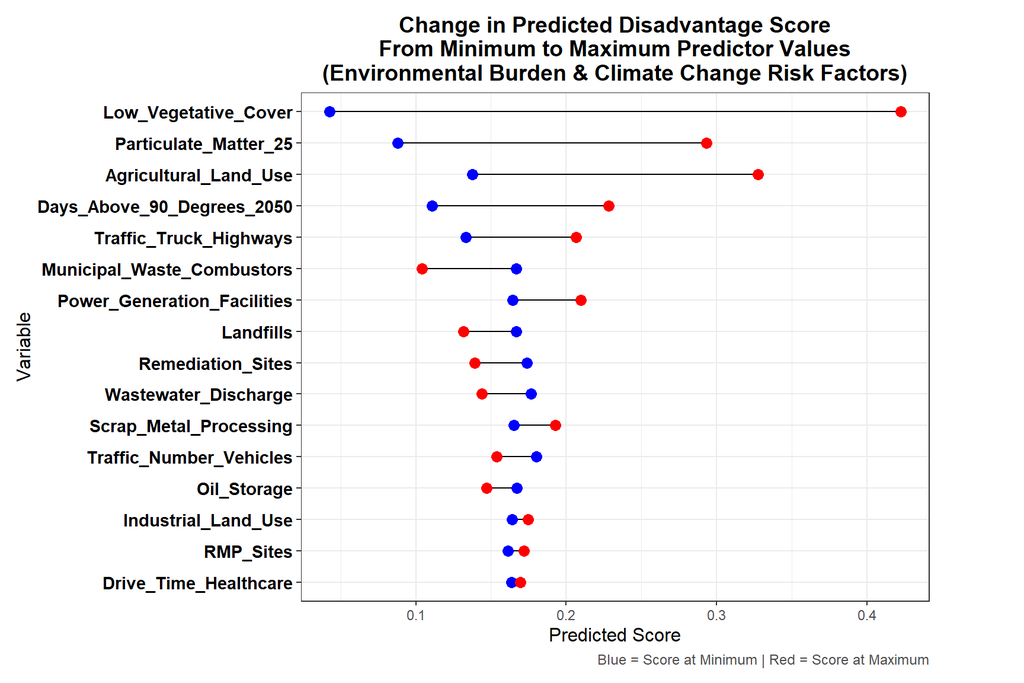

The dumbbell plot provides a visual summary of the predicted change in neighborhood disadvantage score as each environmental and climate-related predictor increases from its minimum to maximum observed value, based on the beta regression model (m2). Each line represents a variable, with the blue dot showing the predicted score at the lowest value and the red dot showing the score at the highest value. Longer lines indicate a greater impact on the predicted disadvantage score.

### Strongest-Impact Predictors

- Low_Vegetative_Cover shows the largest change in predicted score, increasing from approximately 0.04 to 0.42, highlighting the strong relationship between lack of greenery and increased disadvantage.
- Particulate_Matter_25 (PM2.5) and Agricultural_Land_Use also have large increases in predicted scores, suggesting that both air pollution and land use patterns are important contributors to environmental inequity.
- Days_Above_90_Degrees_2050, a proxy for climate risk, shows a substantial impact, reinforcing the relevance of projected extreme heat as a future vulnerability factor.

### Variables Where Higher Values Lower the Predicted Score

- Remediation_Sites: Interpretation: As the number of remediation sites increases, the predicted disadvantage score decreases slightly.

Possible Explanation: This may reflect areas that have received targeted investment for environmental cleanup, infrastructure redevelopment, or policy attention, which could be mitigating disadvantage over time.

- Wastewater_Discharge Interpretation: Higher levels of wastewater discharge are associated with lower predicted scores. Possible Explanation: This could be a proxy for industrial infrastructure, which may be more common in areas with higher economic activity—not necessarily aligned with high disadvantage in all cases. It may also indicate areas where discharge is monitored or regulated, which could overlap with environmental enforcement.

#### Why this matters

These exceptions highlight the complexity of interpreting environmental exposure data. While many factors increase predicted disadvantage scores (as expected in burdened communities), others may behave differently due to:

Policy interventions (e.g., remediation funding),

Spatial characteristics (e.g., industrial zones not always overlapping with residential disadvantage),

Or measurement nuances (e.g., proximity vs. exposure vs. regulation).

# Population and Health Factors Regression Analysis

After evaluating the role of environmental burdens and climate change risk in shaping neighborhood disadvantage, I expanded our analysis to include a broader set of population, socioeconomic, and health-related factors. These indicators capture structural inequities that go beyond environmental exposure, reflecting disparities in healthcare access, chronic illness, housing quality, racial and ethnic composition, economic hardship, and more. To assess the influence of these variables, I developed a second beta regression model (m3) using the same transformed disadvantage score as the outcome. This allowed me to examine how demographic vulnerability and underlying health conditions contribute to patterns of disadvantage across NYC neighborhoods, complementing the environmental findings from the previous model.

## Population and Health Variables Data Dictionary

Before running the regression analysis for the m3 model, I first created a data dictionary to clearly define each of the variables included in the model. This step was essential for ensuring a transparent and well-documented analytical process, especially given the range and complexity of population, socioeconomic, and health-related indicators used. By compiling concise definitions for each variable—such as racial and ethnic composition, chronic health conditions, household composition, education level, income thresholds, and housing characteristics, I ensured a consistent understanding of what each measure represents. This not only facilitated accurate model interpretation but also laid the groundwork for clearly communicating findings to diverse audiences, including policymakers, researchers, and community stakeholders.

Data Dictionary for Population Characteristics & Health Variables (Model m3)

| Variable | Definition |
| --- | --- |
| Asian_Percent | Percent of population identifying as Asian. |
| Black_African_American_Percent | Percent of population identifying as Black or African American. |
| Redlining_Updated | Indicator for whether the area was historically redlined (HOLC maps). |
| Latino_Percent | Percent of population identifying as Latino or Hispanic. |
| English_Proficiency | Percent of population with limited English proficiency. |
| Native_Indigenous | Percent of population identifying as Native or Indigenous. |
| LMI_80_AMI | Percent of households below 80% of Area Median Income (AMI). |
| LMI_Poverty_Federal | Percent of population below the federal poverty level. |
| Population_No_College | Percent of adult population with no college education. |
| Household_Single_Parent | Percent of households led by a single parent. |
| Unemployment_Rate | Unemployment rate in the tract. |
| Asthma_ED_Rate | Emergency department visits due to asthma (per capita). |
| COPD_ED_Rate | Emergency department visits due to COPD (per capita). |
| Households_Disabled | Percent of households with at least one person with a disability. |
| Low_Birth_Weight | Percent of births considered low birth weight. |
| MI_Hospitalization_Rate | Hospitalization rate due to myocardial infarction (heart attacks). |
| Health_Insurance_Rate | Percent of population without health insurance coverage. |
| Age_Over_65 | Percent of population age 65 or older. |
| Premature_Deaths | Rate of premature deaths in the tract. |
| Internet_Access | Percent of households with access to internet service. |
| Home_Energy_Affordability | Estimated household energy cost burden as a percent of income. |
| Homes_Built_Before_1960 | Percent of housing units built before 1960. |
| Rent_Percent_Income | Median rent as a percent of household income. |
| Renter_Percent | Percent of housing units that are renter-occupied. |

To ensure consistency with the previous model, I began our analysis of population and health-related factors using the same beta regression framework applied in m2. This approach is ideal for modeling the transformed disadvantage score, which is a continuous proportion bounded between 0 and 1. By maintaining the same modeling structure, I was able to directly compare the effects of demographic and health-related variables on disadvantage in a way that aligns with the environmental risk factors assessed earlier. In this model, referred to as m3, I included predictors such as rates of chronic illness (e.g., asthma and COPD), disability, poverty, race/ethnicity, education, age, and access to resources like health insurance and internet. This allowed me to quantify how these structural and health-based vulnerabilities shape neighborhood disadvantage across New York City.

```
##
## Call:
## betareg(formula = score_transformed ~ Asian_Percent + Black_African_American_Percent +
##     Redlining_Updated + Latino_Percent + English_Proficiency + Native_Indigenous +
##     LMI_80_AMI + LMI_Poverty_Federal + Population_No_College + Household_Single_Parent +
##     Unemployment_Rate + Asthma_ED_Rate + COPD_ED_Rate + Households_Disabled +
##     Low_Birth_Weight + MI_Hospitalization_Rate + Health_Insurance_Rate +
##     Age_Over_65 + Premature_Deaths + Internet_Access + Home_Energy_Affordability +
##     Homes_Built_Before_1960 + Rent_Percent_Income + Renter_Percent, data = neighborhoods)
##
## Quantile residuals:
##     Min      1Q  Median      3Q     Max
## -4.8714 -0.4558  0.0705  0.5865  3.1032
##
## Coefficients (mean model with logit link):
##                                 Estimate Std. Error z value Pr(>|z|)
## (Intercept)                    -3.764465   0.165012 -22.813  < 2e-16 ***
## Asian_Percent                   0.104009   0.092109   1.129 0.258814
## Black_African_American_Percent -0.667534   0.128545  -5.193 2.07e-07 ***
## Redlining_Updated               1.150143   0.080903  14.216  < 2e-16 ***
## Latino_Percent                  1.139559   0.121501   9.379  < 2e-16 ***
## English_Proficiency             0.652937   0.117871   5.539 3.04e-08 ***
## Native_Indigenous              -0.010918   0.064557  -0.169 0.865706
## LMI_80_AMI                     -0.002463   0.001585  -1.554 0.120234
## LMI_Poverty_Federal             0.549821   0.143360   3.835 0.000125 ***
## Population_No_College           0.358932   0.138456   2.592 0.009531 **
## Household_Single_Parent         0.308251   0.101872   3.026 0.002479 **
## Unemployment_Rate               0.141693   0.086313   1.642 0.100667
## Asthma_ED_Rate                  4.275106   0.193620  22.080  < 2e-16 ***
## COPD_ED_Rate                   -3.625382   0.129307 -28.037  < 2e-16 ***
## Households_Disabled            -0.513834   0.100326  -5.122 3.03e-07 ***
## Low_Birth_Weight               -0.928449   0.141122  -6.579 4.73e-11 ***
## MI_Hospitalization_Rate         0.537703   0.092035   5.842 5.15e-09 ***
## Health_Insurance_Rate           0.336740   0.096208   3.500 0.000465 ***
## Age_Over_65                     0.616298   0.110170   5.594 2.22e-08 ***
## Premature_Deaths                0.297739   0.138457   2.150 0.031523 *
## Internet_Access                 0.218467   0.112939   1.934 0.053067 .
## Home_Energy_Affordability      -0.543592   0.123137  -4.415 1.01e-05 ***
## Homes_Built_Before_1960        -0.305146   0.090530  -3.371 0.000750 ***
## Rent_Percent_Income             0.221799   0.097779   2.268 0.023306 *
## Renter_Percent                  0.217938   0.166730   1.307 0.191168
##
## Phi coefficients (precision model with identity link):
##       Estimate Std. Error z value Pr(>|z|)
## (phi)   2.3509     0.0628   37.44   <2e-16 ***
## ---
## Signif. codes:  0 '***' 0.001 '**' 0.01 '*' 0.05 '.' 0.1 ' ' 1
##
## Type of estimator: ML (maximum likelihood)
## Log-likelihood:  3870 on 26 Df
## Pseudo R-squared:  0.66
## Number of iterations: 101 (BFGS) + 1 (Fisher scoring)
```

Beta Regression Results for Population and Health Predictors (Model m3)

| component | Predictor | Estimate | Standard Error | Z Value | P Value |
| --- | --- | --- | --- | --- | --- |
| mean | (Intercept) | -3.7645 | 0.1650 | -22.8133 | 0.0000 |
| mean | Asian_Percent | 0.1040 | 0.0921 | 1.1292 | 0.2588 |
| mean | Black_African_American_Percent | -0.6675 | 0.1285 | -5.1930 | 0.0000 |
| mean | Redlining_Updated | 1.1501 | 0.0809 | 14.2163 | 0.0000 |
| mean | Latino_Percent | 1.1396 | 0.1215 | 9.3790 | 0.0000 |
| mean | English_Proficiency | 0.6529 | 0.1179 | 5.5394 | 0.0000 |
| mean | Native_Indigenous | -0.0109 | 0.0646 | -0.1691 | 0.8657 |
| mean | LMI_80_AMI | -0.0025 | 0.0016 | -1.5538 | 0.1202 |
| mean | LMI_Poverty_Federal | 0.5498 | 0.1434 | 3.8352 | 0.0001 |
| mean | Population_No_College | 0.3589 | 0.1385 | 2.5924 | 0.0095 |
| mean | Household_Single_Parent | 0.3083 | 0.1019 | 3.0259 | 0.0025 |
| mean | Unemployment_Rate | 0.1417 | 0.0863 | 1.6416 | 0.1007 |
| mean | Asthma_ED_Rate | 4.2751 | 0.1936 | 22.0799 | 0.0000 |
| mean | COPD_ED_Rate | -3.6254 | 0.1293 | -28.0371 | 0.0000 |
| mean | Households_Disabled | -0.5138 | 0.1003 | -5.1216 | 0.0000 |
| mean | Low_Birth_Weight | -0.9284 | 0.1411 | -6.5791 | 0.0000 |
| mean | MI_Hospitalization_Rate | 0.5377 | 0.0920 | 5.8424 | 0.0000 |
| mean | Health_Insurance_Rate | 0.3367 | 0.0962 | 3.5001 | 0.0005 |
| mean | Age_Over_65 | 0.6163 | 0.1102 | 5.5941 | 0.0000 |
| mean | Premature_Deaths | 0.2977 | 0.1385 | 2.1504 | 0.0315 |
| mean | Internet_Access | 0.2185 | 0.1129 | 1.9344 | 0.0531 |
| mean | Home_Energy_Affordability | -0.5436 | 0.1231 | -4.4145 | 0.0000 |
| mean | Homes_Built_Before_1960 | -0.3051 | 0.0905 | -3.3707 | 0.0007 |
| mean | Rent_Percent_Income | 0.2218 | 0.0978 | 2.2684 | 0.0233 |
| mean | Renter_Percent | 0.2179 | 0.1667 | 1.3071 | 0.1912 |
| precision | (phi) | 2.3509 | 0.0628 | 37.4371 | 0.0000 |

The m3 model assesses how structural, demographic, and health-related vulnerabilities are associated with the disadvantage score across NYC neighborhoods. With a pseudo R-squared of 0.66, the model explains approximately 66% of the variation in the transformed disadvantage score—a strong model fit given the complexity of the predictors involved.

## Visualization of Model-Based Predictions at Minimum and Maximum Values for Population and Health Risk Factors

Just like in model m2, I applied the same simulation-based approach to the m3 model to visualize the effect of each population and health-related predictor on the predicted disadvantage score. After fitting the m3 beta regression model, I created a list of variables (vars) that includes all predictors used in the model, excluding Mobile_Homes due to the variable containing negligible or zero values across NYC neighborhoods Using purrr::map_dfr(), I generated a new data set that simulates two scenarios for each variable: one where the variable is set to its minimum observed value, and another where it is set to its maximum, while holding all other variables constant. These values are labeled as “Minimum” and “Maximum” in the “Score Scaling” column, with corresponding “Score Value”s of 0 and 1.

The predictions() function from the marginaleffects package was then used to estimate the predicted disadvantage score for each of these scenarios. The results were compiled into a clean table (m3_table) that shows how each predictor affects the score across its observed range, including lower and upper confidence intervals. This method allows us to directly compare the practical effect of each population and health-related variable on disadvantage, offering a more intuitive interpretation of variable importance than raw model coefficients alone.

Predicted Disadvantage Scores at Minimum and Maximum Predictor Values (Model m3)

| Variable | Score Scaling | Score Value | Predicted Score | Lower Level Confidence Interval | Upper Level Confidence Interval |
| --- | --- | --- | --- | --- | --- |
| Age_Over_65 | Maximum | 1 | 0.3856992 | 0.3545863 | 0.4168121 |
| Age_Over_65 | Minimum | 0 | 0.2531797 | 0.2340960 | 0.2722635 |
| Asian_Percent | Maximum | 1 | 0.3149724 | 0.2957716 | 0.3341731 |
| Asian_Percent | Minimum | 0 | 0.2929741 | 0.2700494 | 0.3158987 |
| Asthma_ED_Rate | Maximum | 1 | 0.6793067 | 0.6480206 | 0.7105929 |
| Asthma_ED_Rate | Minimum | 0 | 0.0286977 | 0.0218501 | 0.0355452 |
| Black_African_American_Percent | Maximum | 1 | 0.2513626 | 0.2305165 | 0.2722088 |
| Black_African_American_Percent | Minimum | 0 | 0.3956021 | 0.3584351 | 0.4327692 |
| COPD_ED_Rate | Maximum | 1 | 0.0592940 | 0.0512158 | 0.0673723 |
| COPD_ED_Rate | Minimum | 0 | 0.7024461 | 0.6768887 | 0.7280036 |
| English_Proficiency | Maximum | 1 | 0.3667724 | 0.3421449 | 0.3913999 |
| English_Proficiency | Minimum | 0 | 0.2316486 | 0.2066701 | 0.2566270 |
| Health_Insurance_Rate | Maximum | 1 | 0.3360130 | 0.3161372 | 0.3558887 |
| Health_Insurance_Rate | Minimum | 0 | 0.2654459 | 0.2424316 | 0.2884601 |
| Home_Energy_Affordability | Maximum | 1 | 0.2620501 | 0.2418207 | 0.2822794 |
| Home_Energy_Affordability | Minimum | 0 | 0.3714254 | 0.3394122 | 0.4034385 |
| Homes_Built_Before_1960 | Maximum | 1 | 0.2814433 | 0.2653092 | 0.2975773 |
| Homes_Built_Before_1960 | Minimum | 0 | 0.3470046 | 0.3203452 | 0.3736640 |
| Household_Single_Parent | Maximum | 1 | 0.3355294 | 0.3134656 | 0.3575931 |
| Household_Single_Parent | Minimum | 0 | 0.2706095 | 0.2473062 | 0.2939128 |
| Households_Disabled | Maximum | 1 | 0.2522277 | 0.2314101 | 0.2730453 |
| Households_Disabled | Minimum | 0 | 0.3605357 | 0.3366293 | 0.3844421 |
| Internet_Access | Maximum | 1 | 0.3261435 | 0.3027962 | 0.3494907 |
| Internet_Access | Minimum | 0 | 0.2800635 | 0.2536595 | 0.3064675 |
| LMI_80_AMI | Maximum | 1 | 0.2855904 | 0.2596732 | 0.3115075 |
| LMI_80_AMI | Minimum | 0 | 0.3383699 | 0.2945809 | 0.3821588 |
| LMI_Poverty_Federal | Maximum | 1 | 0.3547744 | 0.3269648 | 0.3825841 |
| LMI_Poverty_Federal | Minimum | 0 | 0.2408658 | 0.2093453 | 0.2723863 |
| Latino_Percent | Maximum | 1 | 0.4085047 | 0.3837260 | 0.4332833 |
| Latino_Percent | Minimum | 0 | 0.1809819 | 0.1586306 | 0.2033333 |
| Low_Birth_Weight | Maximum | 1 | 0.2332588 | 0.2121069 | 0.2544106 |
| Low_Birth_Weight | Minimum | 0 | 0.4348391 | 0.3927416 | 0.4769366 |
| MI_Hospitalization_Rate | Maximum | 1 | 0.3666825 | 0.3432019 | 0.3901631 |
| MI_Hospitalization_Rate | Minimum | 0 | 0.2527588 | 0.2342324 | 0.2712851 |
| Native_Indigenous | Maximum | 1 | 0.3039584 | 0.2857032 | 0.3222137 |
| Native_Indigenous | Minimum | 0 | 0.3062732 | 0.2921343 | 0.3204121 |
| Population_No_College | Maximum | 1 | 0.3430982 | 0.3122988 | 0.3738975 |
| Population_No_College | Minimum | 0 | 0.2672980 | 0.2383943 | 0.2962018 |
| Premature_Deaths | Maximum | 1 | 0.3322140 | 0.3055353 | 0.3588926 |
| Premature_Deaths | Minimum | 0 | 0.2697552 | 0.2373899 | 0.3021205 |
| Redlining_Updated | Maximum | 1 | 0.4212200 | 0.4016487 | 0.4407912 |
| Redlining_Updated | Minimum | 0 | 0.1893447 | 0.1742923 | 0.2043971 |
| Rent_Percent_Income | Maximum | 1 | 0.3271107 | 0.3058468 | 0.3483747 |
| Rent_Percent_Income | Minimum | 0 | 0.2802785 | 0.2574772 | 0.3030797 |
| Renter_Percent | Maximum | 1 | 0.3218308 | 0.2951110 | 0.3485507 |
| Renter_Percent | Minimum | 0 | 0.2762162 | 0.2330132 | 0.3194192 |
| Unemployment_Rate | Maximum | 1 | 0.3186517 | 0.3001579 | 0.3371456 |
| Unemployment_Rate | Minimum | 0 | 0.2887079 | 0.2673022 | 0.3101135 |

## Key Findings from the m3 Model Prediction Table

The simulation results for the m3 model provide valuable insight into how demographic, health, and socioeconomic indicators affect predicted disadvantage scores across NYC neighborhoods. By comparing predicted scores at each variable’s minimum and maximum observed values, we can better understand the practical impact of each factor—beyond just statistical significance.

Overall, these results offer a clearer picture of which population and health-related characteristics have the strongest influence on structural disadvantage. They also provide a more intuitive interpretation than coefficients alone, making the findings more accessible and actionable for policy, planning, and community health initiatives.

## Dumbbell Plot of Simulated Predictor Effects of for Population and Health Risk Factors

Just like in model m2, I visualized the effect of each predictor variable in the m3 model on the predicted disadvantage score using a dumbbell plot. After generating the simulation table (m3_table) showing predicted scores at the minimum and maximum values of each variable, I reshaped the data to calculate the absolute difference in predicted scores (Diff). This allowed us to rank variables by their relative impact on the outcome. Using ggplot2, I plotted the minimum and maximum predicted values for each variable with connected lines, where blue points represent the predicted score at the minimum value and red points represent the score at the maximum. This visual approach highlights which population and health-related factors have the largest influence on disadvantage and complements the model’s numeric output with an intuitive, accessible format. It also allows for easy comparison with the m2 model, helping to identify whether environmental or social vulnerabilities have a stronger effect on predicted disadvantage.

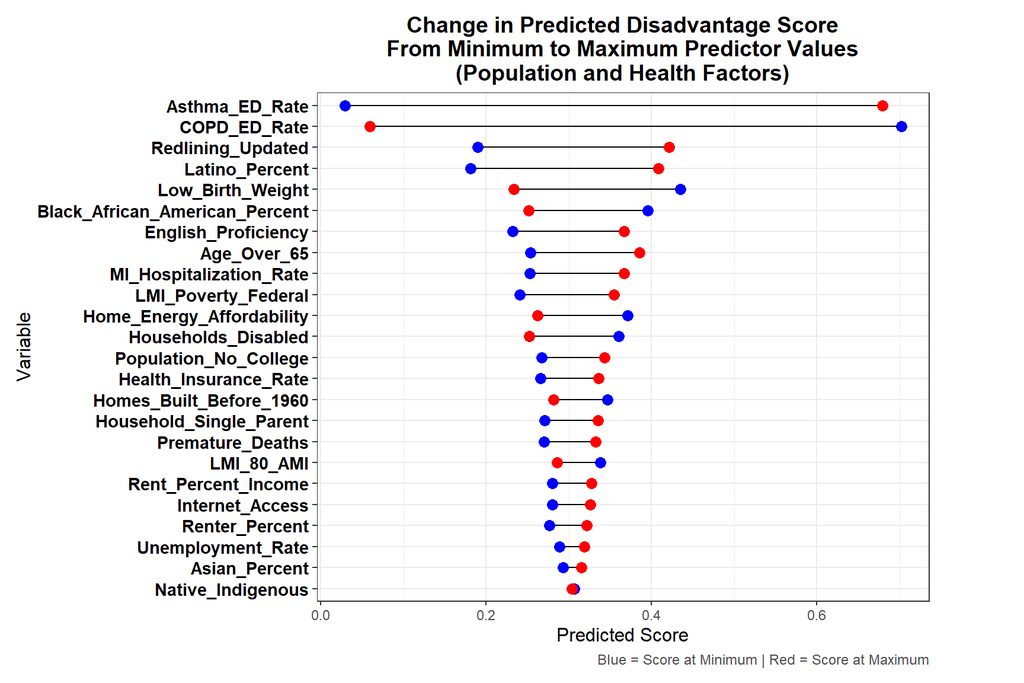

This dumbbell plot visually represents the change in predicted disadvantage scores when each m3 predictor variable increases from its minimum to maximum observed value, while all other variables are held constant. Each variable is plotted along the y-axis, with blue points indicating the predicted score at the minimum value and red points showing the predicted score at the maximum. The longer the connecting line, the greater the variable’s influence on predicted disadvantage.

### Strongest-Impact Predictors

- Asthma_ED_Rate shows the greatest change in predicted disadvantage scores, indicating that neighborhoods with higher asthma-related emergency visits face significantly greater structural vulnerability.
- Redlining_Updated shows a substantial increase in predicted disadvantage, confirming the lasting effect of historically discriminatory housing policies.

### Why this matters

# All Factors Combined Regression Analysis

After evaluating the effects of environmental burdens and climate change risk factors (m2) and population and health-related factors (m3) separately, I combined all predictors into a single beta regression model (m1). This comprehensive model allows for a more holistic understanding of how these diverse factors interact to shape neighborhood disadvantage across New York City. By including both sets of variables, I aimed to capture the complex interplay between environmental exposures, demographic vulnerabilities, and health outcomes in determining structural disadvantage.

```
##
## Call:
## betareg(formula = score_transformed ~ Asian_Percent + Black_African_American_Percent +
##     Redlining_Updated + Latino_Percent + English_Proficiency + Native_Indigenous +
##     LMI_80_AMI + LMI_Poverty_Federal + Population_No_College + Household_Single_Parent +
##     Unemployment_Rate + Asthma_ED_Rate + COPD_ED_Rate + Households_Disabled +
##     Low_Birth_Weight + MI_Hospitalization_Rate + Health_Insurance_Rate +
##     Age_Over_65 + Premature_Deaths + Internet_Access + Home_Energy_Affordability +
##     Homes_Built_Before_1960 + Rent_Percent_Income + Renter_Percent +
##     Particulate_Matter_25 + Traffic_Truck_Highways + Traffic_Number_Vehicles +
##     Wastewater_Discharge + Industrial_Land_Use + Landfills + Oil_Storage +
##     Municipal_Waste_Combustors + Power_Generation_Facilities + RMP_Sites +
##     Remediation_Sites + Scrap_Metal_Processing + Agricultural_Land_Use +
##     Days_Above_90_Degrees_2050 + Low_Vegetative_Cover + Drive_Time_Healthcare,
##     data = neighborhoods)
##
## Quantile residuals:
##     Min      1Q  Median      3Q     Max
## -5.8026 -0.4457  0.1179  0.6159  3.3669
##
## Coefficients (mean model with logit link):
##                                  Estimate Std. Error z value Pr(>|z|)
## (Intercept)                    -9.0695833  0.2272735 -39.906  < 2e-16 ***
## Asian_Percent                   0.0444079  0.0839089   0.529 0.596640
## Black_African_American_Percent -0.1239258  0.1179422  -1.051 0.293381
## Redlining_Updated               0.7725727  0.0784239   9.851  < 2e-16 ***
## Latino_Percent                  0.9820379  0.1183867   8.295  < 2e-16 ***
## English_Proficiency             0.4677137  0.1082070   4.322 1.54e-05 ***
## Native_Indigenous               0.1939146  0.0583131   3.325 0.000883 ***
## LMI_80_AMI                     -0.0003393  0.0014256  -0.238 0.811892
## LMI_Poverty_Federal             0.8141875  0.1309570   6.217 5.06e-10 ***
## Population_No_College           0.4474751  0.1266683   3.533 0.000411 ***
## Household_Single_Parent         0.3459106  0.0916667   3.774 0.000161 ***
## Unemployment_Rate               0.2725396  0.0774701   3.518 0.000435 ***
## Asthma_ED_Rate                  2.7125600  0.1916491  14.154  < 2e-16 ***
## COPD_ED_Rate                   -2.0796916  0.1357996 -15.314  < 2e-16 ***
## Households_Disabled             0.1224058  0.0917151   1.335 0.181997
## Low_Birth_Weight               -0.0638051  0.1358054  -0.470 0.638478
## MI_Hospitalization_Rate         0.3735098  0.0911588   4.097 4.18e-05 ***
## Health_Insurance_Rate           0.2613904  0.0879765   2.971 0.002967 **
```

[output cut: 19 more lines]

```
## Agricultural_Land_Use           1.6602346  0.1980767   8.382  < 2e-16 ***
## Days_Above_90_Degrees_2050      0.9822409  0.1026357   9.570  < 2e-16 ***
## Low_Vegetative_Cover            2.3146570  0.1461894  15.833  < 2e-16 ***
## Drive_Time_Healthcare           1.4926620  0.1170061  12.757  < 2e-16 ***
##
## Phi coefficients (precision model with identity link):
##       Estimate Std. Error z value Pr(>|z|)
## (phi)   3.8990     0.1091   35.75   <2e-16 ***
## ---
## Signif. codes:  0 '***' 0.001 '**' 0.01 '*' 0.05 '.' 0.1 ' ' 1
##
## Type of estimator: ML (maximum likelihood)
## Log-likelihood:  4362 on 42 Df
## Pseudo R-squared: 0.7758
## Number of iterations: 146 (BFGS) + 8 (Fisher scoring)
```

Beta Regression Results for All Factors (Model m1)

| component | Predictor | Estimate | Standard Error | Z Value | P Value |
| --- | --- | --- | --- | --- | --- |
| mean | (Intercept) | -9.0696 | 0.2273 | -39.9060 | 0.0000 |
| mean | Asian_Percent | 0.0444 | 0.0839 | 0.5292 | 0.5966 |
| mean | Black_African_American_Percent | -0.1239 | 0.1179 | -1.0507 | 0.2934 |
| mean | Redlining_Updated | 0.7726 | 0.0784 | 9.8512 | 0.0000 |
| mean | Latino_Percent | 0.9820 | 0.1184 | 8.2952 | 0.0000 |
| mean | English_Proficiency | 0.4677 | 0.1082 | 4.3224 | 0.0000 |
| mean | Native_Indigenous | 0.1939 | 0.0583 | 3.3254 | 0.0009 |
| mean | LMI_80_AMI | -0.0003 | 0.0014 | -0.2380 | 0.8119 |
| mean | LMI_Poverty_Federal | 0.8142 | 0.1310 | 6.2172 | 0.0000 |
| mean | Population_No_College | 0.4475 | 0.1267 | 3.5327 | 0.0004 |
| mean | Household_Single_Parent | 0.3459 | 0.0917 | 3.7736 | 0.0002 |
| mean | Unemployment_Rate | 0.2725 | 0.0775 | 3.5180 | 0.0004 |
| mean | Asthma_ED_Rate | 2.7126 | 0.1916 | 14.1538 | 0.0000 |
| mean | COPD_ED_Rate | -2.0797 | 0.1358 | -15.3144 | 0.0000 |
| mean | Households_Disabled | 0.1224 | 0.0917 | 1.3346 | 0.1820 |
| mean | Low_Birth_Weight | -0.0638 | 0.1358 | -0.4698 | 0.6385 |
| mean | MI_Hospitalization_Rate | 0.3735 | 0.0912 | 4.0974 | 0.0000 |
| mean | Health_Insurance_Rate | 0.2614 | 0.0880 | 2.9711 | 0.0030 |
| mean | Age_Over_65 | 0.4158 | 0.0994 | 4.1823 | 0.0000 |
| mean | Premature_Deaths | 0.0729 | 0.1297 | 0.5619 | 0.5742 |
| mean | Internet_Access | 0.1680 | 0.1010 | 1.6631 | 0.0963 |
| mean | Home_Energy_Affordability | -0.4519 | 0.1156 | -3.9087 | 0.0001 |
| mean | Homes_Built_Before_1960 | -0.2116 | 0.0872 | -2.4251 | 0.0153 |
| mean | Rent_Percent_Income | 0.2329 | 0.0884 | 2.6342 | 0.0084 |
| mean | Renter_Percent | -0.0168 | 0.1614 | -0.1043 | 0.9169 |
| mean | Particulate_Matter_25 | 2.4160 | 0.1344 | 17.9816 | 0.0000 |
| mean | Traffic_Truck_Highways | 0.7930 | 0.1247 | 6.3574 | 0.0000 |
| mean | Traffic_Number_Vehicles | 0.0681 | 0.1353 | 0.5036 | 0.6145 |
| mean | Wastewater_Discharge | -0.2832 | 0.0677 | -4.1839 | 0.0000 |
| mean | Industrial_Land_Use | -0.2037 | 0.0697 | -2.9237 | 0.0035 |
| mean | Landfills | -0.1666 | 0.5642 | -0.2953 | 0.7678 |
| mean | Oil_Storage | 0.0279 | 0.1428 | 0.1951 | 0.8453 |
| mean | Municipal_Waste_Combustors | -1.5746 | 0.7479 | -2.1052 | 0.0353 |
| mean | Power_Generation_Facilities | 0.3968 | 0.1015 | 3.9096 | 0.0001 |
| mean | RMP_Sites | -0.0046 | 0.0011 | -4.1861 | 0.0000 |
| mean | Remediation_Sites | -0.0325 | 0.0749 | -0.4345 | 0.6639 |
| mean | Scrap_Metal_Processing | 0.0072 | 0.1475 | 0.0486 | 0.9613 |
| mean | Agricultural_Land_Use | 1.6602 | 0.1981 | 8.3818 | 0.0000 |
| mean | Days_Above_90_Degrees_2050 | 0.9822 | 0.1026 | 9.5702 | 0.0000 |
| mean | Low_Vegetative_Cover | 2.3147 | 0.1462 | 15.8333 | 0.0000 |
| mean | Drive_Time_Healthcare | 1.4927 | 0.1170 | 12.7571 | 0.0000 |
| precision | (phi) | 3.8990 | 0.1091 | 35.7534 | 0.0000 |

## Visualization of Model-Based Predictions at Minimum and Maximum Values for All Factors

Predicted Disadvantage Scores at Minimum and Maximum Predictor Values (Model m1)

| Variable | Score Scaling | Score Value | Predicted Score | Lower Level Confidence Interval | Upper Level Confidence Interval |
| --- | --- | --- | --- | --- | --- |
| Age_Over_65 | Maximum | 1 | 0.3314049 | 0.3051515 | 0.3576584 |
| Age_Over_65 | Minimum | 0 | 0.2464453 | 0.2295561 | 0.2633345 |
| Agricultural_Land_Use | Maximum | 1 | 0.6565347 | 0.5724984 | 0.7405711 |
| Agricultural_Land_Use | Minimum | 0 | 0.2665212 | 0.2583500 | 0.2746924 |
| Asian_Percent | Maximum | 1 | 0.2843054 | 0.2678966 | 0.3007143 |
| Asian_Percent | Minimum | 0 | 0.2753567 | 0.2552529 | 0.2954605 |
| Asthma_ED_Rate | Maximum | 1 | 0.5138429 | 0.4784635 | 0.5492223 |
| Asthma_ED_Rate | Minimum | 0 | 0.0656531 | 0.0508122 | 0.0804939 |
| Black_African_American_Percent | Maximum | 1 | 0.2704302 | 0.2505145 | 0.2903460 |
| Black_African_American_Percent | Minimum | 0 | 0.2955634 | 0.2658354 | 0.3252914 |
| COPD_ED_Rate | Maximum | 1 | 0.1133954 | 0.0983778 | 0.1284130 |
| COPD_ED_Rate | Minimum | 0 | 0.5054652 | 0.4736437 | 0.5372866 |
| Days_Above_90_Degrees_2050 | Maximum | 1 | 0.3546822 | 0.3365378 | 0.3728266 |
| Days_Above_90_Degrees_2050 | Minimum | 0 | 0.1708576 | 0.1514908 | 0.1902243 |
| Drive_Time_Healthcare | Maximum | 1 | 0.5146051 | 0.4753781 | 0.5538321 |
| Drive_Time_Healthcare | Minimum | 0 | 0.1924886 | 0.1791595 | 0.2058177 |
| English_Proficiency | Maximum | 1 | 0.3219599 | 0.3007800 | 0.3431398 |
| English_Proficiency | Minimum | 0 | 0.2292602 | 0.2065469 | 0.2519736 |
| Health_Insurance_Rate | Maximum | 1 | 0.3029990 | 0.2858788 | 0.3201193 |
| Health_Insurance_Rate | Minimum | 0 | 0.2507817 | 0.2305407 | 0.2710227 |
| Home_Energy_Affordability | Maximum | 1 | 0.2460521 | 0.2280300 | 0.2640742 |
| Home_Energy_Affordability | Minimum | 0 | 0.3326055 | 0.3040581 | 0.3611529 |
| Homes_Built_Before_1960 | Maximum | 1 | 0.2645659 | 0.2499241 | 0.2792077 |
| Homes_Built_Before_1960 | Minimum | 0 | 0.3077089 | 0.2837254 | 0.3316924 |
| Household_Single_Parent | Maximum | 1 | 0.3128683 | 0.2937282 | 0.3320084 |
| Household_Single_Parent | Minimum | 0 | 0.2436716 | 0.2241058 | 0.2632374 |
| Households_Disabled | Maximum | 1 | 0.2933075 | 0.2725278 | 0.3140873 |
| Households_Disabled | Minimum | 0 | 0.2685967 | 0.2499578 | 0.2872356 |
| Industrial_Land_Use | Maximum | 1 | 0.2491841 | 0.2277860 | 0.2705822 |
| Industrial_Land_Use | Minimum | 0 | 0.2905727 | 0.2801823 | 0.3009632 |
| Internet_Access | Maximum | 1 | 0.2956014 | 0.2757954 | 0.3154074 |
| Internet_Access | Minimum | 0 | 0.2618507 | 0.2392075 | 0.2844939 |
| LMI_80_AMI | Maximum | 1 | 0.2777786 | 0.2548693 | 0.3006879 |
| LMI_80_AMI | Minimum | 0 | 0.2846362 | 0.2488249 | 0.3204475 |
| LMI_Poverty_Federal | Maximum | 1 | 0.3518607 | 0.3266431 | 0.3770783 |
| LMI_Poverty_Federal | Minimum | 0 | 0.1938699 | 0.1692602 | 0.2184796 |
| Landfills | Maximum | 1 | 0.2480974 | 0.0419981 | 0.4541968 |
| Landfills | Minimum | 0 | 0.2804614 | 0.2727896 | 0.2881333 |
| Latino_Percent | Maximum | 1 | 0.3651626 | 0.3423178 | 0.3880073 |
| Latino_Percent | Minimum | 0 | 0.1772539 | 0.1559454 | 0.1985624 |
| Low_Birth_Weight | Maximum | 1 | 0.2753335 | 0.2529560 | 0.2977111 |
| Low_Birth_Weight | Minimum | 0 | 0.2882367 | 0.2544039 | 0.3220696 |
| Low_Vegetative_Cover | Maximum | 1 | 0.4166976 | 0.3966562 | 0.4367389 |
| Low_Vegetative_Cover | Minimum | 0 | 0.0659273 | 0.0525848 | 0.0792697 |
| MI_Hospitalization_Rate | Maximum | 1 | 0.3205966 | 0.2991156 | 0.3420776 |
| MI_Hospitalization_Rate | Minimum | 0 | 0.2451990 | 0.2275321 | 0.2628659 |
| Municipal_Waste_Combustors | Maximum | 1 | 0.0747875 | -0.0265901 | 0.1761650 |
| Municipal_Waste_Combustors | Minimum | 0 | 0.2807397 | 0.2730658 | 0.2884137 |
| Native_Indigenous | Maximum | 1 | 0.3042491 | 0.2877972 | 0.3207009 |
| Native_Indigenous | Minimum | 0 | 0.2648210 | 0.2531341 | 0.2765080 |
| Oil_Storage | Maximum | 1 | 0.2859201 | 0.2296895 | 0.3421507 |
| Oil_Storage | Minimum | 0 | 0.2802654 | 0.2724719 | 0.2880590 |
| Particulate_Matter_25 | Maximum | 1 | 0.4624816 | 0.4394693 | 0.4854938 |
| Particulate_Matter_25 | Minimum | 0 | 0.0713693 | 0.0592527 | 0.0834860 |
| Population_No_College | Maximum | 1 | 0.3257709 | 0.2983122 | 0.3532295 |
| Population_No_College | Minimum | 0 | 0.2359962 | 0.2117313 | 0.2602610 |
| Power_Generation_Facilities | Maximum | 1 | 0.3600864 | 0.3167686 | 0.4034042 |
| Power_Generation_Facilities | Minimum | 0 | 0.2745218 | 0.2664024 | 0.2826412 |
| Premature_Deaths | Maximum | 1 | 0.2865633 | 0.2636234 | 0.3095032 |
| Premature_Deaths | Minimum | 0 | 0.2719043 | 0.2415539 | 0.3022546 |
| RMP_Sites | Maximum | 1 | 0.2473815 | 0.2308782 | 0.2638849 |
| RMP_Sites | Minimum | 0 | 0.3430402 | 0.3110833 | 0.3749971 |
| Redlining_Updated | Maximum | 1 | 0.3534932 | 0.3360320 | 0.3709544 |
| Redlining_Updated | Minimum | 0 | 0.2030836 | 0.1879313 | 0.2182358 |
| Remediation_Sites | Maximum | 1 | 0.2748350 | 0.2486850 | 0.3009850 |
| Remediation_Sites | Minimum | 0 | 0.2813651 | 0.2725763 | 0.2901539 |
| Rent_Percent_Income | Maximum | 1 | 0.3022365 | 0.2838584 | 0.3206146 |
| Rent_Percent_Income | Minimum | 0 | 0.2554922 | 0.2360613 | 0.2749230 |
| Renter_Percent | Maximum | 1 | 0.2792143 | 0.2555825 | 0.3028460 |
| Renter_Percent | Minimum | 0 | 0.2826154 | 0.2402906 | 0.3249401 |
| Scrap_Metal_Processing | Maximum | 1 | 0.2818236 | 0.2240729 | 0.3395743 |
| Scrap_Metal_Processing | Minimum | 0 | 0.2803753 | 0.2726045 | 0.2881460 |
| Traffic_Number_Vehicles | Maximum | 1 | 0.2853694 | 0.2644173 | 0.3063215 |
| Traffic_Number_Vehicles | Minimum | 0 | 0.2716794 | 0.2372704 | 0.3060884 |
| Traffic_Truck_Highways | Maximum | 1 | 0.3514922 | 0.3269141 | 0.3760704 |
| Traffic_Truck_Highways | Minimum | 0 | 0.1969460 | 0.1734592 | 0.2204327 |
| Unemployment_Rate | Maximum | 1 | 0.3051090 | 0.2889250 | 0.3212931 |
| Unemployment_Rate | Minimum | 0 | 0.2505605 | 0.2329712 | 0.2681498 |
| Wastewater_Discharge | Maximum | 1 | 0.2418046 | 0.2231485 | 0.2604606 |
| Wastewater_Discharge | Minimum | 0 | 0.2974186 | 0.2861546 | 0.3086825 |

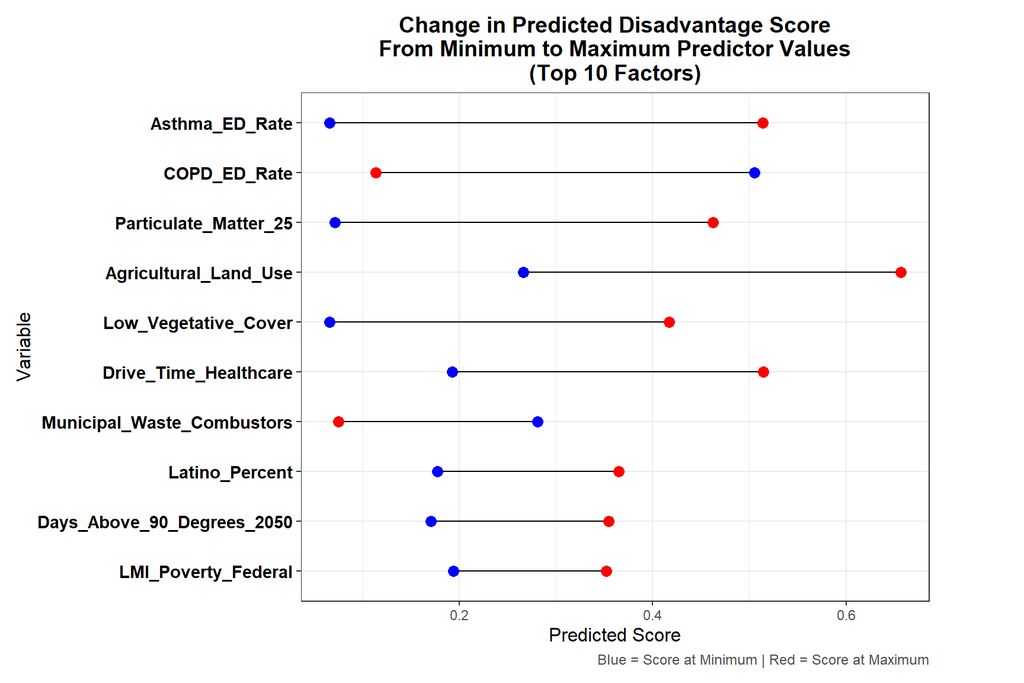

This dumbbell plot visually represents the change in predicted disadvantage scores when each m1 predictor variable increases from its minimum to maximum observed value, while all other variables are held constant. Each variable is plotted along the y-axis, with blue points indicating the predicted score at the minimum value and red points showing the predicted score at the maximum. The longer the connecting line, the greater the variable’s influence on predicted disadvantage.

## Why This Matters

This analysis highlights how certain environmental and health-related variables carry significant weight in predicting structural disadvantage across NYC neighborhoods. Importantly, not all relationships are linear or intuitive. For example, while asthma and PM2.5 are clearly linked to greater vulnerability, some industrial indicators or health stats show inverse patterns—underscoring the complexity of urban systems. These findings can guide targeted interventions in the most impacted communities and support policies focused on reducing environmental harm, improving healthcare access, and addressing historical injustices.

# Conclusion

Ultimately, this analysis affirms the utility of the Disadvantage Score as both a diagnostic and strategic tool. By pinpointing which structural factors most influence disadvantage—and recognizing their overlap with public health and safety concerns like gun violence—this work supports targeted, equity-driven interventions that address root causes rather than symptoms. Moving forward, this research provides a data-informed foundation for public health, urban planning, and community safety efforts aimed at reducing violence and promoting neighborhood resilience across New York City.

— Michael Morello